# Homework 3

Nghia Le

February 8, 2019

### **Part A**

```r
library(MASS)
Boston
attach(Boston)
```

The Boston data frame has 506 rows and 14 columns. We have descriptions of columns as follow:

- `crim`: per capita crime rate by town.
- `zn`: proportion of residential land zoned for lots over 25,000 sq.ft.
- `indus`: proportion of non-retail business acres per town.
- `chas`: Charles River dummy variable (= 1 if tract bounds river; 0 otherwise).
- `nox`: nitrogen oxides concentration (parts per 10 million).
- `rm`: average number of rooms per dwelling.
- `age`: proportion of owner-occupied units built prior to 1940.
- `dis`: weighted mean of distances to five Boston employment centres.
- `rad`: index of accessibility to radial highways.
- `tax`: full-value property-tax rate per $10,000.
- `ptratio`: pupil-teacher ratio by town.
- `black`: 1000(Bk - 0.63)^2 where Bk is the proportion of blacks by town.
- `lstat`: lower status of the population (percent).
- `medv`: median value of owner-occupied homes in $1000s.

### **Part B**

First let see summary of the predictors

```r
summary(Boston)
```

```
##       crim                zn             indus            chas
##  Min.   : 0.00632   Min.   :  0.00   Min.   : 0.46   Min.   :0.00000
##  1st Qu.: 0.08204   1st Qu.:  0.00   1st Qu.: 5.19   1st Qu.:0.00000
##  Median : 0.25651   Median :  0.00   Median : 9.69   Median :0.00000
##  Mean   : 3.61352   Mean   : 11.36   Mean   :11.14   Mean   :0.06917
##  3rd Qu.: 3.67708   3rd Qu.: 12.50   3rd Qu.:18.10   3rd Qu.:0.00000
##  Max.   :88.97620   Max.   :100.00   Max.   :27.74   Max.   :1.00000
##       nox               rm             age              dis
##  Min.   :0.3850   Min.   :3.561   Min.   :  2.90   Min.   : 1.130
##  1st Qu.:0.4490   1st Qu.:5.886   1st Qu.: 45.02   1st Qu.: 2.100
##  Median :0.5380   Median :6.208   Median : 77.50   Median : 3.207
##  Mean   :0.5547   Mean   :6.285   Mean   : 68.57   Mean   : 3.795
##  3rd Qu.:0.6240   3rd Qu.:6.623   3rd Qu.: 94.08   3rd Qu.: 5.188
##  Max.   :0.8710   Max.   :8.780   Max.   :100.00   Max.   :12.127
##       rad              tax           ptratio          black
##  Min.   : 1.000   Min.   :187.0   Min.   :12.60   Min.   :  0.32
##  1st Qu.: 4.000   1st Qu.:279.0   1st Qu.:17.40   1st Qu.:375.38
##  Median : 5.000   Median :330.0   Median :19.05   Median :391.44
##  Mean   : 9.549   Mean   :408.2   Mean   :18.46   Mean   :356.67
##  3rd Qu.:24.000   3rd Qu.:666.0   3rd Qu.:20.20   3rd Qu.:396.23
##  Max.   :24.000   Max.   :711.0   Max.   :22.00   Max.   :396.90
##      lstat            medv
##  Min.   : 1.73   Min.   : 5.00
##  1st Qu.: 6.95   1st Qu.:17.02
##  Median :11.36   Median :21.20
##  Mean   :12.65   Mean   :22.53
##  3rd Qu.:16.95   3rd Qu.:25.00
##  Max.   :37.97   Max.   :50.00
```

We now take a look at the correlation matrix

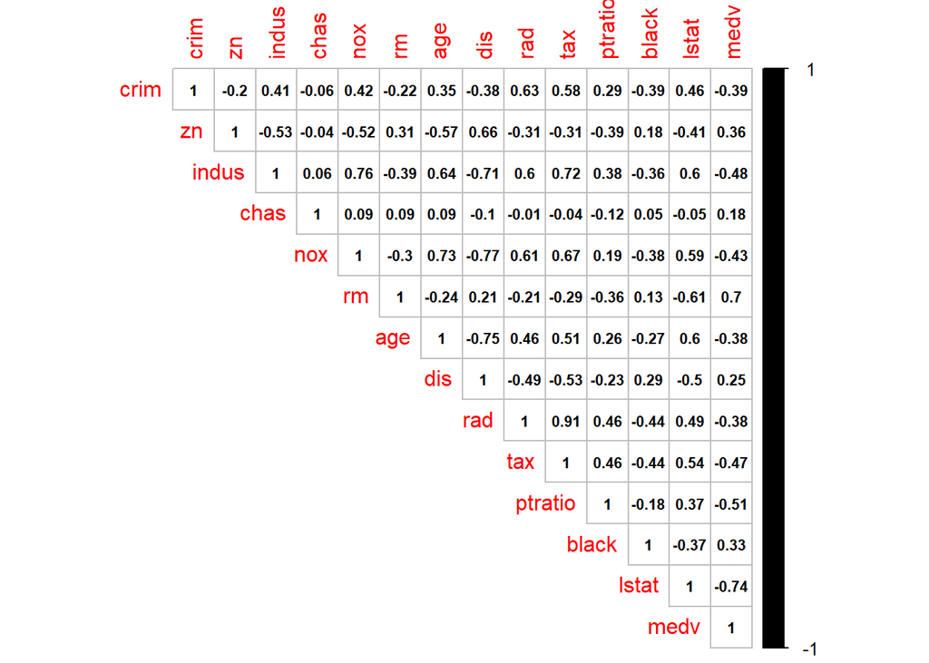

```r
library(corrplot)
corr_matrix<-cor(Boston)
corrplot(corr_matrix, method="number", number.cex = .7, col="black", type="upper")
```

Let see some pairwise scatterplots:

Between `lstat` and `medv`

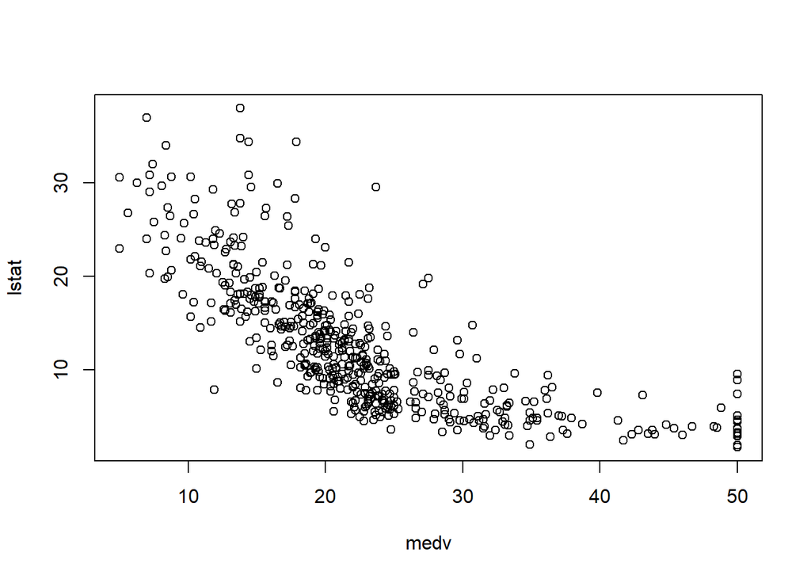

```r
plot(medv,lstat)
```

Between `rm` and `medv`

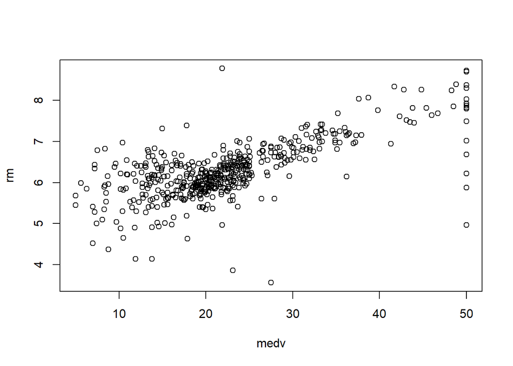

```r
plot(medv,rm)
```

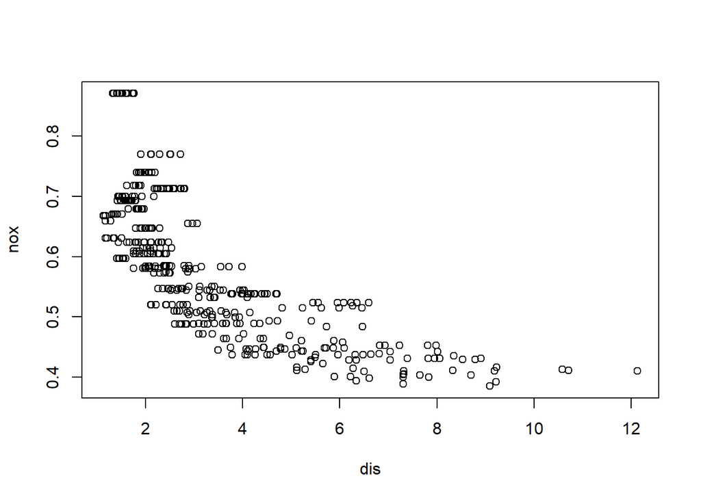

```r
plot(dis,nox)
```

Between `age` and `nox`

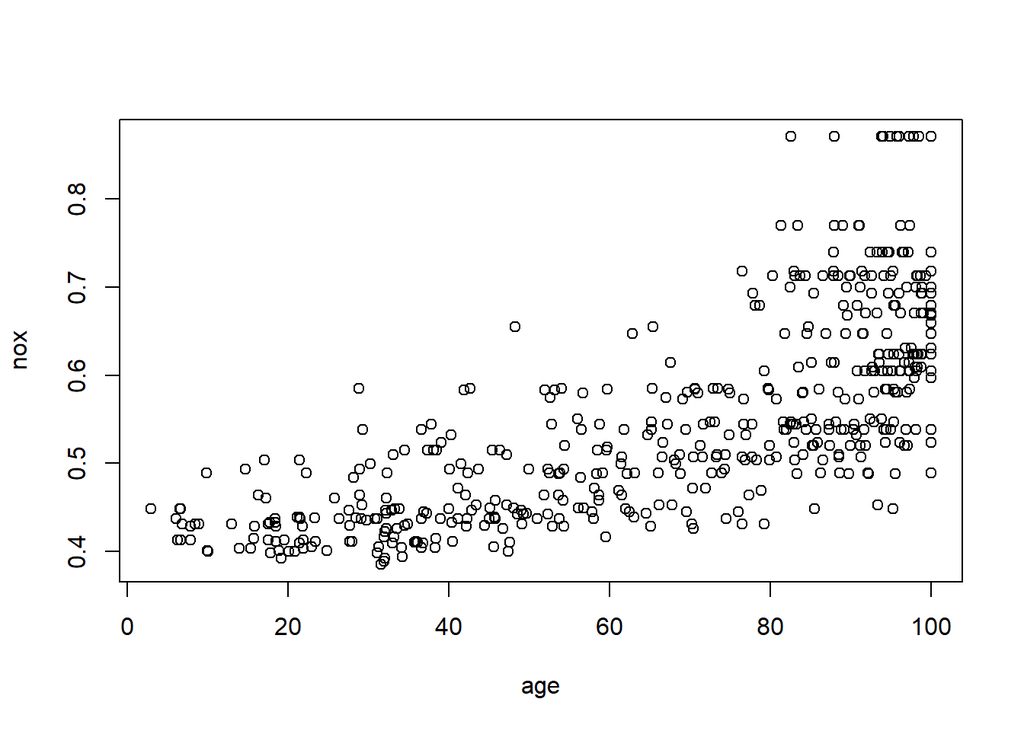

```r
plot(age,nox)
```

**Conclusion:** From the plot above we can conclude that there is strong correlation between following pairs of predictors:

`lstat` and `medv`

`rm` and `medv`

`tax` and `rad`

`age` and `nox`

### **Part C**

From the correlation matrix we can see that there are significant levels of correlation between `crim` and these predictors:

- `indus`
- `nox`
- `rad`
- `tax`
- `lstat`

The correlation coefficient between `crim` and above predictors is positive, it means that as the value of one variable increases, the value of the other variable increases; as one decreases the other decreases.

### **Part D**

First, let look at the histogram of `crim`, `tax` and `ptratio`:

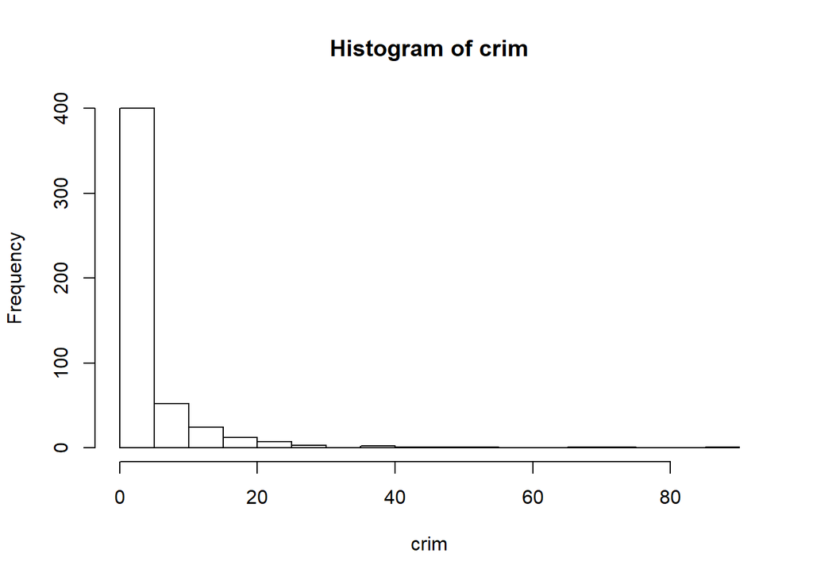

```r
hist(crim, breaks=25)
```

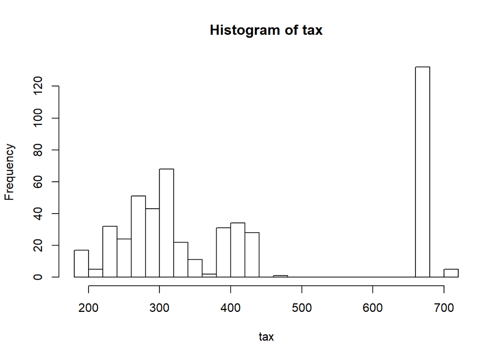

```r
hist(tax, breaks=25)
```

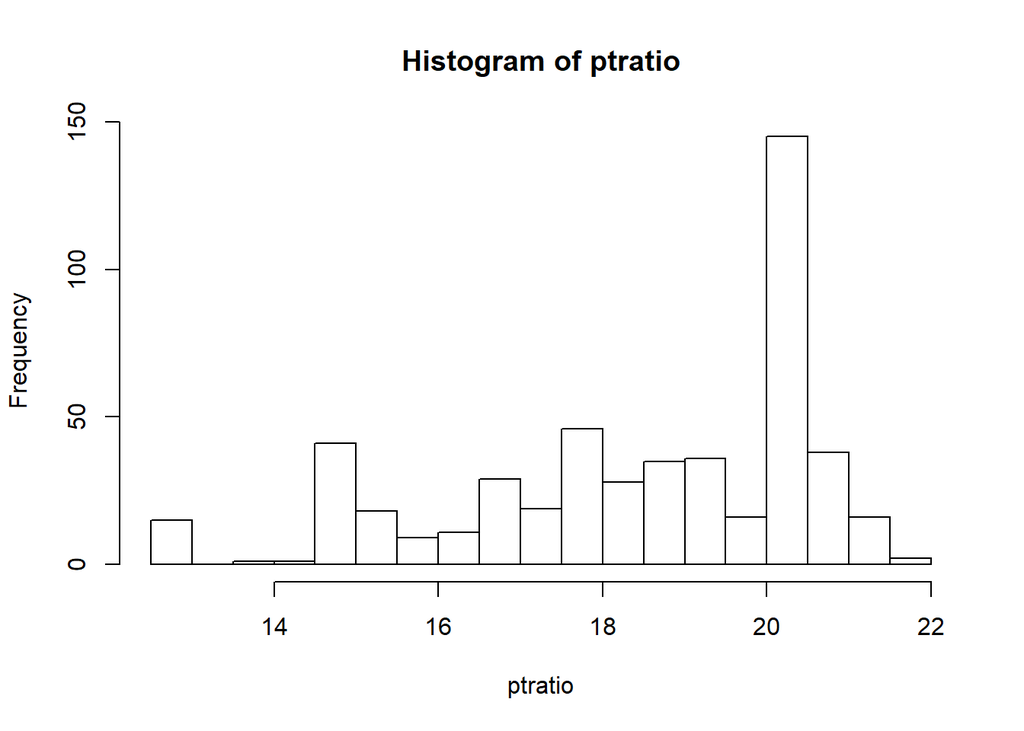

```r
hist(ptratio, breaks=25)
```

Majority of Boston suburb have low crim rates, however there are suburbs in Boston that have very high crime rate but the frequency is low.

However, we should set a standard for *“particularly high crime rate”*, a suburb that has particularly high crime rate means crime rate in that suburb **is above third quartile**, which is **3.677**.

Let see how many suburb in Boston that fits the criterion:

```r
sum(crim > 3.677)
```

```
## [1] 127
```

Same defination can be applied for **Tax rates** and **Pupil-teacher ratios**.

For **Tax rates**:

```r
sum(tax > 666)
```

```
## [1] 5
```

For **Pupil-teacher ratios**:

```r
sum(ptratio > 20.2)
```

```
## [1] 56
```

### **Part E**

The number of suburb that is bounded by Charles river is:

```r
sum(chas == 1)
```

```
## [1] 35
```

### **Part F**

The median pupil-teacher ratio among the towns in this data set is:

```r
median(ptratio)
```

```
## [1] 19.05
```

### **Part G**

Let see the suburbs with lowest median value and other predictors that are associated with it:

```r
t(subset(Boston, medv == min(medv)))
```

```
##              399      406
## crim     38.3518  67.9208
## zn        0.0000   0.0000
## indus    18.1000  18.1000
## chas      0.0000   0.0000
## nox       0.6930   0.6930
## rm        5.4530   5.6830
## age     100.0000 100.0000
## dis       1.4896   1.4254
## rad      24.0000  24.0000
## tax     666.0000 666.0000
## ptratio  20.2000  20.2000
## black   396.9000 384.9700
## lstat    30.5900  22.9800
## medv      5.0000   5.0000
```

Comparing with the summary of Boston:

|  | 399 | 406 | Comparision |
| --- | --- | --- | --- |
| crim | 38.3518 | 67.9208 | above 3rd quartile |
| zn | 0.0000 | 0.0000 | Minimum |
| indus | 18.1000 | 18.1000 | at 3rd quartile |
| chas | 0.0000 | 0.0000 | not bounded by river |
| nox | 0.6930 | 0.6930 | above 3rd quartile |
| rm | 5.4530 | 5.6830 | below 1st quartile |
| age | 100.0000 | 100.0000 | Maximum |
| dis | 1.4896 | 1.4254 | below 1st quartile |
| rad | 24.0000 | 24.0000 | Maximum |
| tax | 666.0000 | 666.0000 | at 3rd quartile |
| ptratio | 20.2000 | 20.2000 | at 3rd quartile |
| black | 396.9000 | 384.9700 | Maximum, above 1st quartile |
| lstat | 30.5900 | 22.9800 | above 3rd quartile |
| medv | 5.0000 | 5.0000 | Minimum |

As expected, these suburbs has very bad attributes, high crime rate, high tax rate, very polluted and the portion of population with low status is high.

### **Part H**

The number of suburbs average more than seven rooms per dwelling:

```r
sum(rm > 7)
```

```
## [1] 64
```

The number of suburbs average more than eight rooms per dwelling:

```r
sum(rm > 8)
```

```
## [1] 13
```

Let see attributes of suburbs that average more than eight rooms per dwelling:

```r
summary(subset(Boston, rm > 8))
```

```
##       crim               zn            indus             chas
##  Min.   :0.02009   Min.   : 0.00   Min.   : 2.680   Min.   :0.0000
##  1st Qu.:0.33147   1st Qu.: 0.00   1st Qu.: 3.970   1st Qu.:0.0000
##  Median :0.52014   Median : 0.00   Median : 6.200   Median :0.0000
##  Mean   :0.71879   Mean   :13.62   Mean   : 7.078   Mean   :0.1538
##  3rd Qu.:0.57834   3rd Qu.:20.00   3rd Qu.: 6.200   3rd Qu.:0.0000
##  Max.   :3.47428   Max.   :95.00   Max.   :19.580   Max.   :1.0000
##       nox               rm             age             dis
##  Min.   :0.4161   Min.   :8.034   Min.   : 8.40   Min.   :1.801
##  1st Qu.:0.5040   1st Qu.:8.247   1st Qu.:70.40   1st Qu.:2.288
##  Median :0.5070   Median :8.297   Median :78.30   Median :2.894
##  Mean   :0.5392   Mean   :8.349   Mean   :71.54   Mean   :3.430
##  3rd Qu.:0.6050   3rd Qu.:8.398   3rd Qu.:86.50   3rd Qu.:3.652
##  Max.   :0.7180   Max.   :8.780   Max.   :93.90   Max.   :8.907
##       rad              tax           ptratio          black
##  Min.   : 2.000   Min.   :224.0   Min.   :13.00   Min.   :354.6
##  1st Qu.: 5.000   1st Qu.:264.0   1st Qu.:14.70   1st Qu.:384.5
##  Median : 7.000   Median :307.0   Median :17.40   Median :386.9
##  Mean   : 7.462   Mean   :325.1   Mean   :16.36   Mean   :385.2
##  3rd Qu.: 8.000   3rd Qu.:307.0   3rd Qu.:17.40   3rd Qu.:389.7
##  Max.   :24.000   Max.   :666.0   Max.   :20.20   Max.   :396.9
##      lstat           medv
##  Min.   :2.47   Min.   :21.9
##  1st Qu.:3.32   1st Qu.:41.7
##  Median :4.14   Median :48.3
##  Mean   :4.31   Mean   :44.2
##  3rd Qu.:5.12   3rd Qu.:50.0
##  Max.   :7.44   Max.   :50.0
```

Comparing these attributes with summary of all Boston suburbs:

```r
summary(Boston)
```

```
##       crim                zn             indus            chas
##  Min.   : 0.00632   Min.   :  0.00   Min.   : 0.46   Min.   :0.00000
##  1st Qu.: 0.08204   1st Qu.:  0.00   1st Qu.: 5.19   1st Qu.:0.00000
##  Median : 0.25651   Median :  0.00   Median : 9.69   Median :0.00000
##  Mean   : 3.61352   Mean   : 11.36   Mean   :11.14   Mean   :0.06917
##  3rd Qu.: 3.67708   3rd Qu.: 12.50   3rd Qu.:18.10   3rd Qu.:0.00000
##  Max.   :88.97620   Max.   :100.00   Max.   :27.74   Max.   :1.00000
##       nox               rm             age              dis
##  Min.   :0.3850   Min.   :3.561   Min.   :  2.90   Min.   : 1.130
##  1st Qu.:0.4490   1st Qu.:5.886   1st Qu.: 45.02   1st Qu.: 2.100
##  Median :0.5380   Median :6.208   Median : 77.50   Median : 3.207
##  Mean   :0.5547   Mean   :6.285   Mean   : 68.57   Mean   : 3.795
##  3rd Qu.:0.6240   3rd Qu.:6.623   3rd Qu.: 94.08   3rd Qu.: 5.188
##  Max.   :0.8710   Max.   :8.780   Max.   :100.00   Max.   :12.127
##       rad              tax           ptratio          black
##  Min.   : 1.000   Min.   :187.0   Min.   :12.60   Min.   :  0.32
##  1st Qu.: 4.000   1st Qu.:279.0   1st Qu.:17.40   1st Qu.:375.38
##  Median : 5.000   Median :330.0   Median :19.05   Median :391.44
##  Mean   : 9.549   Mean   :408.2   Mean   :18.46   Mean   :356.67
##  3rd Qu.:24.000   3rd Qu.:666.0   3rd Qu.:20.20   3rd Qu.:396.23
##  Max.   :24.000   Max.   :711.0   Max.   :22.00   Max.   :396.90
##      lstat            medv
##  Min.   : 1.73   Min.   : 5.00
##  1st Qu.: 6.95   1st Qu.:17.02
##  Median :11.36   Median :21.20
##  Mean   :12.65   Mean   :22.53
##  3rd Qu.:16.95   3rd Qu.:25.00
##  Max.   :37.97   Max.   :50.00
```

It is clear that suburbs that average more than eight rooms have lower crime rate, the portion of low status population is very low, mean and median tax rate are lower than mean and median tax rate of all Boston suburbs.